# 重賞レース予測レポート【レース終了】

作成日時: 2026/01/12 16:11:46

☞ [マニュアル(pdf)](https://ryutoro-galois.github.io/keiba-predictor/manual/manual.pdf)

☞ 過去6年の同一レース結果: [2025年](https://ryutoro-galois.github.io/keiba-predictor/report/PredResult_2025y_raceDate_20250112_20250113.html), [2024年](https://ryutoro-galois.github.io/keiba-predictor/report/PredResult_2024y_raceDate_20240113_20240114.html), [2023年](https://ryutoro-galois.github.io/keiba-predictor/report/PredResult_2023y_raceDate_20230108_20230109.html), [2022年](https://ryutoro-galois.github.io/keiba-predictor/report/PredResult_2022y_raceDate_20220109_20220110.html), [2021年](https://ryutoro-galois.github.io/keiba-predictor/report/PredResult_2021y_raceDate_20210110_20210111.html), [2020年](https://ryutoro-galois.github.io/keiba-predictor/report/PredResult_2020y_raceDate_20200112_20200113.html)

☞ 過去4週間の別レース結果: [1週前(1/4)](https://ryutoro-galois.github.io/keiba-predictor/report/PredResult_2026y_raceDate_20260104_20260104.html), [2週前(12/27-28)](https://ryutoro-galois.github.io/keiba-predictor/report/PredResult_2025y_raceDate_20251227_20251228.html), [3週前(12/20-21)](https://ryutoro-galois.github.io/keiba-predictor/report/PredResult_2025y_raceDate_20251220_20251221.html), [4週前(12/13-14)](https://ryutoro-galois.github.io/keiba-predictor/report/PredResult_2025y_raceDate_20251213_20251214.html)

☞ netkeiba: [フェアリーステークス(GⅢ)](https://race.netkeiba.com/race/result.html?race_id=202606010411&rf=race_submenu), [シンザン記念(GⅢ)](https://race.netkeiba.com/race/result.html?race_id=202608010511&rf=race_submenu)

☞ レース結果(csv): [1/10-12](https://ryutoro-galois.github.io/keiba-predictor/csv/race_result_20260110_20260112.csv)

## 【レース結果(1)】人気と着順の関係

### 【フェアリーステークス(2026/01/11(日))】

【フェアリーステークス(GⅢ)】  
2026/01/11(日), 06_中山, 芝右外1600m

[interactive chart not shown]

### 【シンザン記念(2026/01/12(月))】

【シンザン記念(GⅢ)】  
2026/01/12(月), 08_京都, 芝右外1600m

[interactive chart not shown]

## 【レース結果(2)】コーナー通過順位

### 【フェアリーステークス(2026/01/11(日))】

【フェアリーステークス(GⅢ)】  
2026/01/11(日), 06_中山, 芝右外1600m

[interactive chart not shown]

### 【シンザン記念(2026/01/12(月))】

【シンザン記念(GⅢ)】  
2026/01/12(月), 08_京都, 芝右外1600m

[interactive chart not shown]

## 0. 推し馬予測 (AI予測)

### 【フェアリーステークス(GⅢ) 2026/01/11(日)】

- 本命(◎): 1-3着内確率(勝負強さ)が1位の馬
- 対抗(◯): 1-3着内確率が2-N位(20%程度以上)の中で予測タイムが最も速い馬
- 3番手(▲): 1-3着内確率が2-N位(20%程度以上)のでダークホース確率が最も高い馬
- 穴: ダークホース確率が上位1-M位(40%程度以上)の中で1-3着内確率が最も高い馬

| 推し馬 | 枠番 | 馬番 | 人気 | オッズ | 馬名 | 騎手 | 調教師 | 予測タイム(sec) | 1_順位 | 1-3着内確率(%) | 2_順位 | ﾀﾞｰｸﾎｰｽ確率(%) | 3_順位 |
| --- | --- | --- | --- | --- | --- | --- | --- | --- | --- | --- | --- | --- | --- |
| 本命(◎) | 6 | 12 | 2 | 4.7 | ギリーズボール | Ｃ．ルメール | 手塚貴久 | 95.0 | 2 | 52.6 | 1 | 0.4 | 15 |
| 対抗(◯) | 5 | 9 | 3 | 5.2 | サンアントワーヌ | 戸崎圭太 | 鹿戸雄一 | 95.8 | 4 | 41.6 | 2 | 0.5 | 14 |
| 3番手(▲) | 2 | 3 | 6 | 13.6 | トワニ | 菅原明良 | 蛯名正義 | 96.2 | 9 | 22.1 | 4 | 1.4 | 9 |
| 穴 | 3 | 5 | 16 | 93.4 | エゴンウレア | 大野拓弥 | 小手川準 | 95.6 | 3 | 12.9 | 8 | 52.7 | 1 |

### 【シンザン記念(GⅢ) 2026/01/12(月)】

- 本命(◎): 1-3着内確率(勝負強さ)が1位の馬
- 対抗(◯): 1-3着内確率が2-N位(20%程度以上)の中で予測タイムが最も速い馬
- 3番手(▲): 1-3着内確率が2-N位(20%程度以上)のでダークホース確率が最も高い馬
- 穴: ダークホース確率が上位1-M位(40%程度以上)の中で1-3着内確率が最も高い馬

| 推し馬 | 枠番 | 馬番 | 人気 | オッズ | 馬名 | 騎手 | 調教師 | 予測タイム(sec) | 1_順位 | 1-3着内確率(%) | 2_順位 | ﾀﾞｰｸﾎｰｽ確率(%) | 3_順位 |
| --- | --- | --- | --- | --- | --- | --- | --- | --- | --- | --- | --- | --- | --- |
| 本命(◎) | 2 | 4 | 2 | 5.0 | ディアダイヤモンド | 武豊 | 手塚貴久 | 104.2 | 15 | 44.1 | 1 | 0.4 | 14 |
| 対抗(◯) | 1 | 1 | 1 | 4.9 | アルトラムス | 岩田望来 | 野中賢二 | 93.8 | 3 | 23.2 | 4 | 0.4 | 15 |
| 穴 | 7 | 14 | 16 | 108.6 | プレダトゥール | 亀田温心 | 北出成人 | 93.8 | 3 | 9.2 | 8 | 43.0 | 2 |

## 1. 予測チャート (タイム/勝負強さ)

### 【フェアリーステークス(GⅢ)】

2026/01/11(日), 06_中山, 芝右外1600m

[interactive chart not shown]

### 【シンザン記念(GⅢ)】

2026/01/12(月), 08_京都, 芝右外1600m

[interactive chart not shown]

## 2. オッズモニタリング (毎時)

### 【フェアリーステークス】

[interactive chart not shown]

### 【シンザン記念】

[interactive chart not shown]

## 3. 出馬表

### 【フェアリーステークス 2026/01/11(日) 】

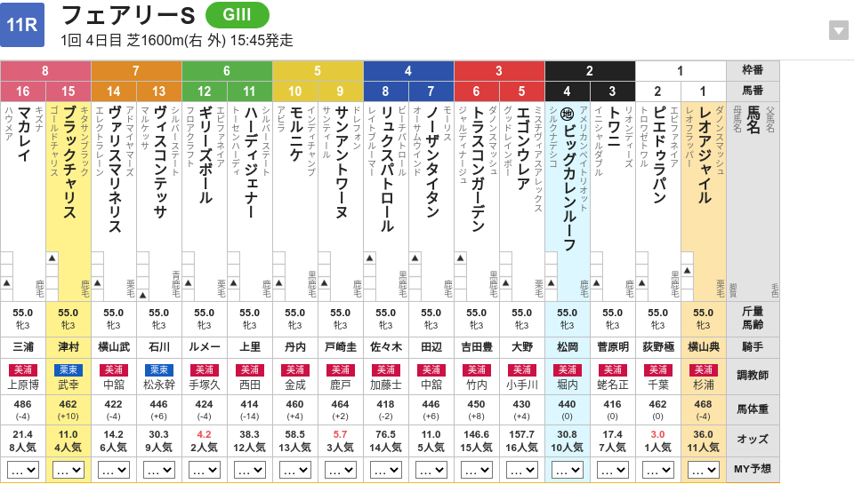

### 【シンザン記念 2026/01/12(月) 】

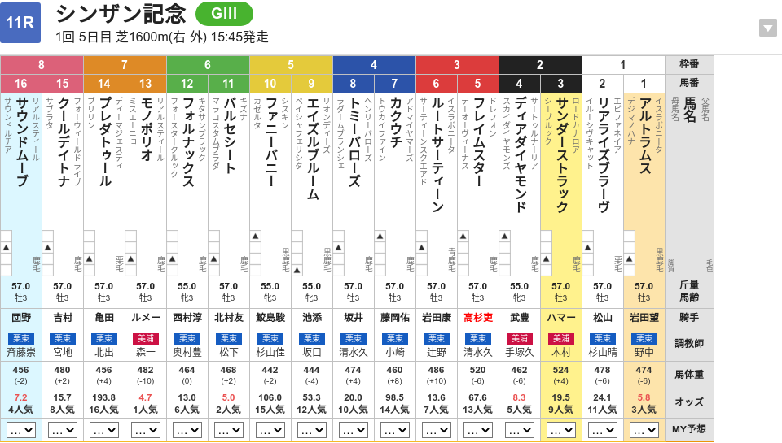

## 4. 単勝予測結果

### 【フェアリーステークス(GⅢ) 2026/01/11(日)】

| 枠番 | 馬番 | 人気 | オッズ | 馬名 | 騎手 | 調教師 | 予測タイム(sec) | 1_順位 | 1-3着内確率(%) | 2_順位 | ﾀﾞｰｸﾎｰｽ確率(%) | 3_順位 |
| --- | --- | --- | --- | --- | --- | --- | --- | --- | --- | --- | --- | --- |
| 1 | 1 | 12 | 24.9 | レオアジャイル | 横山典弘 | 杉浦宏昭 | 103.3 | 14 | 3.0 | 14 | 11.0 | 7 |
| 1 | 2 | 1 | 4.5 | ピエドゥラパン | 荻野極 | 千葉直人 | 93.7 | 1 | 13.9 | 7 | 0.4 | 16 |
| 2 | 3 | 6 | 13.6 | トワニ | 菅原明良 | 蛯名正義 | 96.2 | 9 | 22.1 | 4 | 1.4 | 9 |
| 2 | 4 | 11 | 23.0 | ビッグカレンルーフ | 松岡正海 | 堀内岳志 | 103.1 | 12 | 4.7 | 10 | 9.8 | 8 |
| 3 | 5 | 16 | 93.4 | エゴンウレア | 大野拓弥 | 小手川準 | 95.6 | 3 | 12.9 | 8 | 52.7 | 1 |
| 3 | 6 | 15 | 81.4 | トラスコンガーデン | 吉田豊 | 竹内正洋 | 103.1 | 11 | 2.7 | 16 | 12.0 | 6 |
| 4 | 7 | 4 | 9.8 | ノーザンタイタン | 田辺裕信 | 中舘英二 | 96.1 | 7 | 24.7 | 3 | 1.3 | 10 |
| 4 | 8 | 14 | 50.0 | リュクスパトロール | 佐々木大輔 | 加藤士津八 | 95.9 | 5 | 11.5 | 9 | 44.6 | 2 |
| 5 | 9 | 3 | 5.2 | サンアントワーヌ | 戸崎圭太 | 鹿戸雄一 | 95.8 | 4 | 41.6 | 2 | 0.5 | 14 |
| 5 | 10 | 13 | 46.8 | モルニケ | 丹内祐次 | 金成貴史 | 104.2 | 15 | 2.9 | 15 | 27.9 | 3 |

[output cut: 6 more lines]

### 【シンザン記念(GⅢ) 2026/01/12(月)】

| 枠番 | 馬番 | 人気 | オッズ | 馬名 | 騎手 | 調教師 | 予測タイム(sec) | 1_順位 | 1-3着内確率(%) | 2_順位 | ﾀﾞｰｸﾎｰｽ確率(%) | 3_順位 |
| --- | --- | --- | --- | --- | --- | --- | --- | --- | --- | --- | --- | --- |
| 1 | 1 | 1 | 4.9 | アルトラムス | 岩田望来 | 野中賢二 | 93.8 | 3 | 23.2 | 4 | 0.4 | 15 |
| 1 | 2 | 9 | 19.2 | リアライズブラーヴ | 松山弘平 | 杉山晴紀 | 102.4 | 13 | 4.3 | 14 | 19.3 | 7 |
| 2 | 3 | 6 | 13.3 | サンダーストラック | Ｔ．ハマーハンセン | 木村哲也 | 101.7 | 8 | 10.4 | 7 | 1.0 | 11 |
| 2 | 4 | 2 | 5.0 | ディアダイヤモンド | 武豊 | 手塚貴久 | 104.2 | 15 | 44.1 | 1 | 0.4 | 14 |
| 3 | 5 | 13 | 56.7 | フレイムスター | 和田竜二 | 清水久詞 | 101.5 | 7 | 3.5 | 16 | 9.9 | 8 |
| 3 | 6 | 10 | 19.8 | ルートサーティーン | 岩田康誠 | 辻野泰之 | 93.8 | 3 | 11.6 | 6 | 35.7 | 5 |
| 4 | 7 | 14 | 57.1 | カクウチ | 藤岡佑介 | 小崎憲 | 93.8 | 3 | 8.8 | 10 | 47.1 | 1 |
| 4 | 8 | 11 | 24.2 | トミーバローズ | 坂井瑠星 | 清水久詞 | 102.2 | 11 | 7.4 | 12 | 37.5 | 4 |
| 5 | 9 | 12 | 27.2 | エイズルブルーム | 池添謙一 | 坂口智康 | 102.3 | 12 | 7.3 | 13 | 34.7 | 6 |
| 5 | 10 | 15 | 65.3 | ファニーバニー | 鮫島克駿 | 杉山佳明 | 102.0 | 10 | 3.9 | 15 | 43.0 | 3 |

[output cut: 6 more lines]

## 5. 人気と着順の乖離率推移

### 【フェアリーステークス_1994y_2019y】

[interactive chart not shown]

### 【シンザン記念_1990y_2019y】

[interactive chart not shown]

### 【フェアリーステークス_1994y_2019y】

| No | 開催年 | 不整合率(%) | 頭数 | 人気別着順(1-3位) | 人気別着順(全体) |
| --- | --- | --- | --- | --- | --- |
| 25 | 2019 | 55.1 | 16頭 | 3-4-5 | 3\|4\|5\|2\|1\|15\|10\|8\|12\|6\|13\|16\|9\|11\|14\|7 |
| 24 | 2018 | 37.9 | 16頭 | 2-6-7 | 2\|6\|7\|14\|3\|1\|4\|8\|10\|12\|9\|5\|11\|15\|13\|16 |
| 23 | 2017 | 40.7 | 16頭 | 10-1-7 | 10\|1\|7\|11\|12\|4\|13\|3\|14\|5\|9\|2\|6\|8\|15\|16 |
| 22 | 2016 | 54.3 | 16頭 | 3-10-7 | 3\|10\|7\|4\|6\|8\|1\|5\|14\|9\|12\|15\|16\|11\|2\|13 |
| 21 | 2015 | 58.3 | 16頭 | 11-8-3 | 11\|8\|3\|2\|7\|9\|6\|1\|5\|13\|14\|4\|15\|12\|16\|10 |
| 20 | 2014 | 36.8 | 16頭 | 1-10-4 | 1\|10\|4\|5\|3\|12\|6\|13\|8\|2\|11\|15\|14\|7\|9\|16 |
| 19 | 2013 | 37.4 | 16頭 | 10-5-2 | 10\|5\|2\|1\|6\|9\|15\|3\|4\|11\|13\|12\|16\|8\|14\|7 |
| 18 | 2012 | 48.0 | 16頭 | 3-14-5 | 3\|14\|5\|1\|8\|6\|7\|4\|9\|10\|11\|15\|12\|13\|16\|2 |
| 17 | 2011 | 22.4 | 16頭 | 1-7-2 | 1\|7\|2\|4\|14\|5\|11\|13\|8\|6\|12\|10\|15\|3\|9\|16 |
| 16 | 2010 | 26.8 | 16頭 | 11-2-1 | 11\|2\|1\|3\|16\|5\|9\|8\|10\|7\|13\|12\|4\|15\|6\|14 |

[output cut: 15 more lines]

### 【シンザン記念_1990y_2019y】

| No | 開催年 | 不整合率(%) | 頭数 | 人気別着順(1-3位) | 人気別着順(全体) |
| --- | --- | --- | --- | --- | --- |
| 30 | 2019 | 55.5 | 12頭 | 4-10-2 | 4\|10\|2\|5\|3\|11\|7\|1\|6\|12\|9\|8 |
| 29 | 2018 | 18.7 | 11頭 | 1-7-4 | 1\|7\|4\|2\|3\|5\|10\|6\|8\|9\|11 |
| 28 | 2017 | 39.5 | 15頭 | 8-4-1 | 8\|4\|1\|3\|5\|2\|7\|11\|9\|12\|13\|10\|14\|6\|15 |
| 27 | 2016 | 53.0 | 18頭 | 8-2-11 | 8\|2\|11\|3\|6\|7\|10\|12\|5\|13\|16\|9\|4\|1\|17\|14\|15\|18 |
| 26 | 2015 | 34.5 | 12頭 | 2-9-3 | 2\|9\|3\|1\|4\|8\|7\|5\|11\|10\|6\|12 |
| 25 | 2014 | 14.6 | 13頭 | 1-2-5 | 1\|2\|5\|4\|3\|7\|6\|10\|12\|9\|8\|13\|11 |
| 24 | 2013 | 23.1 | 16頭 | 1-9-3 | 1\|9\|3\|2\|4\|14\|8\|10\|6\|11\|12\|7\|5\|16\|15\|13 |
| 23 | 2012 | 31.0 | 15頭 | 2-9-11 | 2\|9\|11\|1\|6\|8\|3\|10\|7\|13\|12\|4\|15\|5\|14 |
| 22 | 2011 | 54.5 | 16頭 | 7-3-6 | 7\|3\|6\|2\|1\|14\|5\|12\|8\|11\|9\|4\|16\|15\|10\|13 |
| 21 | 2010 | 56.2 | 16頭 | 4-9-10 | 4\|9\|10\|13\|6\|14\|5\|16\|8\|2\|1\|7\|3\|12\|11\|15 |

[output cut: 20 more lines]

## 6. 1-3番人気馬の着順分類予測

### 【フェアリーステークス】

| 分類 | 凡例 | 発生確率(%) | 当該レース | 当該レースランク | 直近1年間 |
| --- | --- | --- | --- | --- | --- |
| 1: 1番人気のみ (1_pop1) | 1 \| * \| * | 16.3 | 1.68 | 0.99 | 0.00 |
| 3: 3番人気のみ (3_pop3) | 3 \| * \| * | 15.7 | 0.44 | 0.81 | 0.31 |
| 4: 1,2番人気のみ (4_pop12) | 1 \| 2 \| * | 15.3 | 0.95 | 1.14 | 0.00 |
| 8: 1,2,3番人気すべて着外 (8_darkhorse) | * \| * \| * | 15.1 | 2.32 | 2.52 | 0.00 |
| 5: 1,3番人気のみ (5_pop13) | 1 \| 3 \| * | 12.6 | 1.94 | 1.40 | 0.00 |
| 6: 2,3番人気のみ (6_pop23) | 2 \| 3 \| * | 9.2 | 1.42 | 1.53 | 0.00 |
| 2: 2番人気のみ (2_pop2) | 2 \| * \| * | 8.7 | 0.54 | 0.34 | 0.17 |
| 7: 1,2,3番人気すべて着内 (7_pop123) | 1 \| 2 \| 3 | 7.1 | 2.22 | 1.58 | 0.00 |

### 【シンザン記念】

| 分類 | 凡例 | 発生確率(%) | 当該レース | 当該レースランク | 直近1年間 |
| --- | --- | --- | --- | --- | --- |
| 1: 1番人気のみ (1_pop1) | 1 \| * \| * | 16.0 | 0.72 | 0.98 | 0.00 |
| 2: 2番人気のみ (2_pop2) | 2 \| * \| * | 15.9 | 0.48 | 0.63 | 0.32 |
| 4: 1,2番人気のみ (4_pop12) | 1 \| 2 \| * | 14.9 | 1.34 | 1.11 | 0.00 |
| 8: 1,2,3番人気すべて着外 (8_darkhorse) | * \| * \| * | 14.7 | 2.62 | 2.45 | 0.00 |
| 5: 1,3番人気のみ (5_pop13) | 1 \| 3 \| * | 12.4 | 1.12 | 1.38 | 0.00 |
| 3: 3番人気のみ (3_pop3) | 3 \| * \| * | 10.2 | 1.82 | 0.53 | 0.20 |
| 6: 2,3番人気のみ (6_pop23) | 2 \| 3 \| * | 9.0 | 1.61 | 1.50 | 0.00 |
| 7: 1,2,3番人気すべて着内 (7_pop123) | 1 \| 2 \| 3 | 7.0 | 1.25 | 1.56 | 0.00 |

## 7. 3連複予測結果

### 【フェアリーステークス(GⅢ) 2026/01/11(日)】

| 分類 | 馬番 | 枠番 | 人気 | 平均予測タイム(sec) | 1-3着内確率(%) | ﾀﾞｰｸﾎｰｽ確率(%) | 馬名 | 騎手 | 調教師 |
| --- | --- | --- | --- | --- | --- | --- | --- | --- | --- |
| 6: 2,3番人気のみ (6_pop23) | 12-9-7 | 6-5-4 | 2-3-4 | 95.63 | 5.41 | 0.00 | ギリーズボール \| サンアントワーヌ \| ノーザンタイタン | Ｃ．ルメール \| 戸崎圭太 \| 田辺裕信 | 手塚貴久 \| 鹿戸雄一 \| 中舘英二 |
| 6: 2,3番人気のみ (6_pop23) | 12-9-3 | 6-5-2 | 2-3-6 | 95.67 | 4.84 | 0.00 | ギリーズボール \| サンアントワーヌ \| トワニ | Ｃ．ルメール \| 戸崎圭太 \| 菅原明良 | 手塚貴久 \| 鹿戸雄一 \| 蛯名正義 |
| 6: 2,3番人気のみ (6_pop23) | 12-9-15 | 6-5-8 | 2-3-5 | 95.60 | 4.80 | 0.00 | ギリーズボール \| サンアントワーヌ \| ブラックチャリス | Ｃ．ルメール \| 戸崎圭太 \| 津村明秀 | 手塚貴久 \| 鹿戸雄一 \| 武幸四郎 |
| 6: 2,3番人気のみ (6_pop23) | 12-9-14 | 6-5-7 | 2-3-7 | 95.67 | 4.05 | 0.00 | ギリーズボール \| サンアントワーヌ \| ヴァリスマリネリス | Ｃ．ルメール \| 戸崎圭太 \| 横山武史 | 手塚貴久 \| 鹿戸雄一 \| 中舘英二 |
| 7: 1,2,3番人気すべて着内 (7_pop123) | 2-12-9 | 1-6-5 | 1-2-3 | 94.83 | 3.04 | 0.00 | ピエドゥラパン \| ギリーズボール \| サンアントワーヌ | 荻野極 \| Ｃ．ルメール \| 戸崎圭太 | 千葉直人 \| 手塚貴久 \| 鹿戸雄一 |
| 2: 2番人気のみ (2_pop2) | 12-7-3 | 6-4-2 | 2-4-6 | 95.77 | 2.88 | 0.00 | ギリーズボール \| ノーザンタイタン \| トワニ | Ｃ．ルメール \| 田辺裕信 \| 菅原明良 | 手塚貴久 \| 中舘英二 \| 蛯名正義 |
| 2: 2番人気のみ (2_pop2) | 12-7-15 | 6-4-8 | 2-4-5 | 95.70 | 2.85 | 0.00 | ギリーズボール \| ノーザンタイタン \| ブラックチャリス | Ｃ．ルメール \| 田辺裕信 \| 津村明秀 | 手塚貴久 \| 中舘英二 \| 武幸四郎 |
| 6: 2,3番人気のみ (6_pop23) | 12-9-5 | 6-5-3 | 2-3-16 | 95.47 | 2.82 | 0.00 | ギリーズボール \| サンアントワーヌ \| エゴンウレア | Ｃ．ルメール \| 戸崎圭太 \| 大野拓弥 | 手塚貴久 \| 鹿戸雄一 \| 小手川準 |
| 2: 2番人気のみ (2_pop2) | 12-15-3 | 6-8-2 | 2-5-6 | 95.73 | 2.55 | 0.00 | ギリーズボール \| ブラックチャリス \| トワニ | Ｃ．ルメール \| 津村明秀 \| 菅原明良 | 手塚貴久 \| 武幸四郎 \| 蛯名正義 |
| 6: 2,3番人気のみ (6_pop23) | 12-9-8 | 6-5-4 | 2-3-14 | 95.57 | 2.52 | 0.00 | ギリーズボール \| サンアントワーヌ \| リュクスパトロール | Ｃ．ルメール \| 戸崎圭太 \| 佐々木大輔 | 手塚貴久 \| 鹿戸雄一 \| 加藤士津八 |

[output cut: 550 more lines]

### 【シンザン記念(GⅢ) 2026/01/12(月)】

| 分類 | 馬番 | 枠番 | 人気 | 平均予測タイム(sec) | 1-3着内確率(%) | ﾀﾞｰｸﾎｰｽ確率(%) | 馬名 | 騎手 | 調教師 |
| --- | --- | --- | --- | --- | --- | --- | --- | --- | --- |
| 6: 2,3番人気のみ (6_pop23) | 4-11-13 | 2-6-7 | 2-3-4 | 100.77 | 6.81 | 0.00 | ディアダイヤモンド \| バルセシート \| モノポリオ | 武豊 \| 北村友一 \| Ｃ．ルメール | 手塚貴久 \| 松下武士 \| 森一誠 |
| 7: 1,2,3番人気すべて着内 (7_pop123) | 1-4-11 | 1-2-6 | 1-2-3 | 97.27 | 4.21 | 0.00 | アルトラムス \| ディアダイヤモンド \| バルセシート | 岩田望来 \| 武豊 \| 北村友一 | 野中賢二 \| 手塚貴久 \| 松下武士 |
| 4: 1,2番人気のみ (4_pop12) | 1-4-13 | 1-2-7 | 1-2-4 | 100.77 | 3.84 | 0.00 | アルトラムス \| ディアダイヤモンド \| モノポリオ | 岩田望来 \| 武豊 \| Ｃ．ルメール | 野中賢二 \| 手塚貴久 \| 森一誠 |
| 5: 1,3番人気のみ (5_pop13) | 1-11-13 | 1-6-7 | 1-3-4 | 97.30 | 3.58 | 0.00 | アルトラムス \| バルセシート \| モノポリオ | 岩田望来 \| 北村友一 \| Ｃ．ルメール | 野中賢二 \| 松下武士 \| 森一誠 |
| 6: 2,3番人気のみ (6_pop23) | 4-11-16 | 2-6-8 | 2-3-5 | 99.93 | 2.54 | 0.00 | ディアダイヤモンド \| バルセシート \| サウンドムーブ | 武豊 \| 北村友一 \| 団野大成 | 手塚貴久 \| 松下武士 \| 斉藤崇史 |
| 2: 2番人気のみ (2_pop2) | 4-13-16 | 2-7-8 | 2-4-5 | 103.43 | 2.32 | 0.00 | ディアダイヤモンド \| モノポリオ \| サウンドムーブ | 武豊 \| Ｃ．ルメール \| 団野大成 | 手塚貴久 \| 森一誠 \| 斉藤崇史 |
| 3: 3番人気のみ (3_pop3) | 11-13-16 | 6-7-8 | 3-4-5 | 99.97 | 2.16 | 0.00 | バルセシート \| モノポリオ \| サウンドムーブ | 北村友一 \| Ｃ．ルメール \| 団野大成 | 松下武士 \| 森一誠 \| 斉藤崇史 |
| 6: 2,3番人気のみ (6_pop23) | 4-11-6 | 2-6-3 | 2-3-10 | 97.27 | 2.09 | 0.00 | ディアダイヤモンド \| バルセシート \| ルートサーティーン | 武豊 \| 北村友一 \| 岩田康誠 | 手塚貴久 \| 松下武士 \| 辻野泰之 |
| 2: 2番人気のみ (2_pop2) | 4-13-6 | 2-7-3 | 2-4-10 | 100.77 | 1.91 | 0.00 | ディアダイヤモンド \| モノポリオ \| ルートサーティーン | 武豊 \| Ｃ．ルメール \| 岩田康誠 | 手塚貴久 \| 森一誠 \| 辻野泰之 |
| 6: 2,3番人気のみ (6_pop23) | 4-11-3 | 2-6-2 | 2-3-6 | 99.90 | 1.88 | 0.00 | ディアダイヤモンド \| バルセシート \| サンダーストラック | 武豊 \| 北村友一 \| Ｔ．ハマーハンセン | 手塚貴久 \| 松下武士 \| 木村哲也 |

[output cut: 550 more lines]

## 8. 直近の全レース情報

[output not shown]

[output cut: 2 more lines]